# Adult Income

## Adult Income Project

### For this project, I'll be using the "Adult Income" dataset from the UCI Machine Learning Repository. This dataset contains information about individuals' demographics, education, and income, and our goal will be to use this data to predict whether an individual makes over $50,000 per year.

#### 1- Load the dataset into a dataframe

```python
import pandas as pd
import numpy as np
import matplotlib.pyplot as plt
import seaborn as sns
from sklearn.model_selection import train_test_split
from sklearn.linear_model import LogisticRegression
from sklearn.metrics import confusion_matrix, classification_report

# Load the data into a pandas DataFrame
url = 'https://archive.ics.uci.edu/ml/machine-learning-databases/adult/adult.data'
columns = ['age', 'workclass', 'fnlwgt', 'education', 'education-num', 'marital-status', 'occupation', 'relationship', 'race', 'sex', 'capital-gain', 'capital-loss', 'hours-per-week', 'native-country', 'income']
data = pd.read_csv(url, names=columns)
c=pd.read_csv(url)
print(c)
```

```
       39          State-gov   77516    Bachelors   13        Never-married  \
0      50   Self-emp-not-inc   83311    Bachelors   13   Married-civ-spouse
1      38            Private  215646      HS-grad    9             Divorced
2      53            Private  234721         11th    7   Married-civ-spouse
3      28            Private  338409    Bachelors   13   Married-civ-spouse
4      37            Private  284582      Masters   14   Married-civ-spouse
...    ..                ...     ...          ...  ...                  ...
32555  27            Private  257302   Assoc-acdm   12   Married-civ-spouse
32556  40            Private  154374      HS-grad    9   Married-civ-spouse
32557  58            Private  151910      HS-grad    9              Widowed
32558  22            Private  201490      HS-grad    9        Never-married
32559  52       Self-emp-inc  287927      HS-grad    9   Married-civ-spouse

             Adm-clerical   Not-in-family   White     Male   2174   0   40  \
0         Exec-managerial         Husband   White     Male      0   0   13
```

[output cut: 25 more lines]

#### 2- Drop any rows with missing values

```python
data = data.replace('?', np.nan)
data = data.dropna()
```

#### 3- Convert the target variable to a binary classification problem

```python
data['income'] = (data['income'] == ' >50K')
```

#### 4- Convert categorical variables to numerical

```python
cat_columns = ['workclass', 'education', 'marital-status', 'occupation', 'relationship', 'race', 'sex', 'native-country']
for column in cat_columns:
    data[column] = pd.Categorical(data[column])
    data[column] = data[column].cat.codes
```

#### 5- Split the data into training and testing sets

```python
X = data.drop('income', axis=1)
y = data['income']
X_train, X_test, y_train, y_test = train_test_split(X, y, test_size=0.2, random_state=42)
```

#### 6- Train a logistic regression model

```python
model = LogisticRegression(max_iter=1000)
model.fit(X_train, y_train)
```

```
LogisticRegression(max_iter=1000)
```

#### 7- Evaluate the model on the testing set

```python
y_pred = model.predict(X_test)
print(confusion_matrix(y_test, y_pred))
print(classification_report(y_test, y_pred))
```

```
[[4673  269]
 [1102  469]]
              precision    recall  f1-score   support

       False       0.81      0.95      0.87      4942
        True       0.64      0.30      0.41      1571

    accuracy                           0.79      6513
   macro avg       0.72      0.62      0.64      6513
weighted avg       0.77      0.79      0.76      6513
```

#### 8- Plot a histogram of the predicted probabilities for the positive class

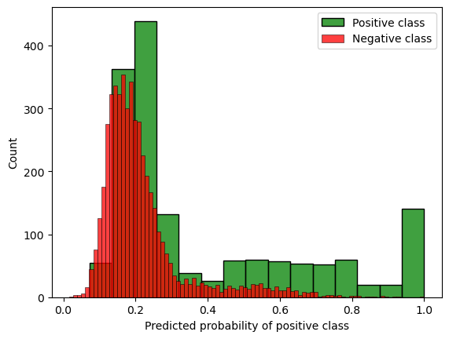

```python
probs = model.predict_proba(X_test)[:,1]
sns.histplot(probs[y_test == 1], kde=False, label='Positive class', color='green')
sns.histplot(probs[y_test == 0], kde=False, label='Negative class', color='red')
plt.legend()
plt.xlabel('Predicted probability of positive class')
plt.ylabel('Count')
plt.show()
```

#### 9- Visualize the number of individuals who make over $50,000 per year and those who do not.

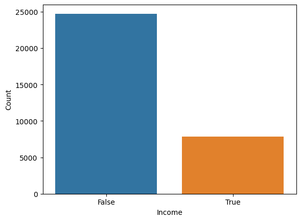

```python
sns.countplot(data=data, x='income')
plt.xlabel('Income')
plt.ylabel('Count')
plt.show()
```

#### 10- Visualize the distribution of age for individuals who make over $50,000 per year and those who do not.

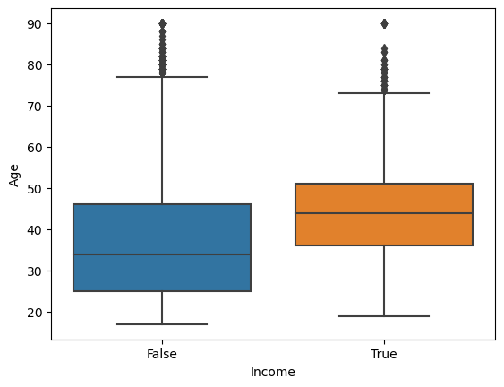

```python
sns.boxplot(data=data, x='income', y='age')
plt.xlabel('Income')
plt.ylabel('Age')
plt.show()
```

#### 11- Visualize the number of individuals who make over $50,000 per year by education level.

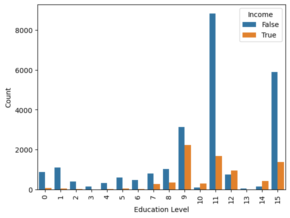

```python
sns.countplot(data=data, x='education', hue='income')
plt.xlabel('Education Level')
plt.ylabel('Count')
plt.legend(title='Income', loc='upper right')
plt.xticks(rotation=90)
plt.show()
```

#### 12- Visualize the trade-off between true positive rate and false positive rate for different thresholds of the predicted probabilities.

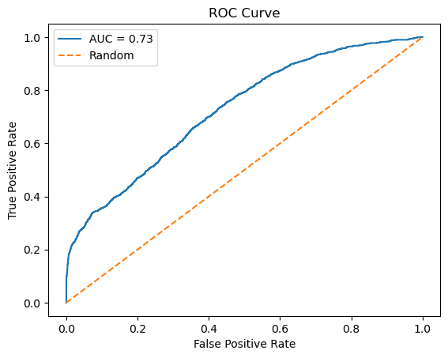

```python
from sklearn.metrics import roc_curve, roc_auc_score

fpr, tpr, thresholds = roc_curve(y_test, probs)
auc = roc_auc_score(y_test, probs)

plt.plot(fpr, tpr, label=f'AUC = {auc:.2f}')
plt.plot([0, 1], [0, 1], linestyle='--', label='Random')
plt.xlabel('False Positive Rate')
plt.ylabel('True Positive Rate')
plt.title('ROC Curve')
plt.legend()
plt.show()
```

#### We can see that our model is performing better than random, with an AUC of 0.73. However, there is still room for improvement, as the curve could be closer to the top-left corner of the plot.

#### 13- Visualize the number of individuals who make over $50,000 per year by occupation.

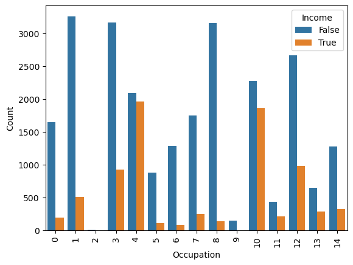

```python
sns.countplot(data=data, x='occupation', hue='income')
plt.xlabel('Occupation')
plt.ylabel('Count')
plt.legend(title='Income', loc='upper right')
plt.xticks(rotation=90)
plt.show()
```

#### 14- Visualize the number of males and females who make over $50,000 per year.

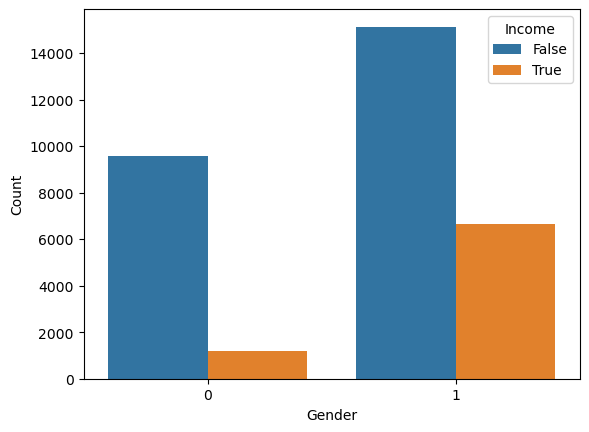

```python
sns.countplot(data=data, x='sex', hue='income')
plt.xlabel('Gender')
plt.ylabel('Count')
plt.legend(title='Income', loc='upper right')
plt.show()
```